# US Commericial Flights

## Preliminary Wrangling

> The Flight data contain ~607K records from the year 2020 taken from the United States Department of Transportation.
- Year - Year of Data record, Quarter - Contains values from 1-4, Day-of-week - 1(Monday) to 7(Sunday)
- DepTime - actual departure time (local, hhmm) and ArrTime - actual arrival time (local, hhmm)
- Distance - Distance between airports (miles)
- Dest,Origin - Destination Airport and Origin Airport
- DestCityName, OriginCityName - Destination Airport and Origin Airport, City Name
- Cancelled - was the flight cancelled?
- CancellationCode - reason for cancellation (A = carrier, B = weather, C = NAS, D = security)
- CarrierDelay - in minutes
- LateAircraftDelay - in minutes
- SecurityDelay - in minutes
- NASDelay - in minutes
- WeatherDelay - in minutes
- ArrDelay - Difference in minutes between scheduled and actual arrival time. Early arrivals show negative numbers.
- DepDelay - Difference in minutes between scheduled and actual departure time. Early departures show negative numbers.

### Importing Libraries

```python
import pandas as pd
import matplotlib.pyplot as plt
import seaborn as sns
import numpy as np

plt.style.use('fivethirtyeight')
```

### The Dataset

```python
df = pd.read_csv('flights.csv')
```

```python
df.shape
```

```
(607346, 36)
```

- Finding null values in dataset!

```python
df.isnull().sum().sort_values(ascending=False)[:14]
```

```
Unnamed: 35            607346
CANCELLATION_CODE      600418
SECURITY_DELAY         525061
NAS_DELAY              525061
WEATHER_DELAY          525061
CARRIER_DELAY          525061
LATE_AIRCRAFT_DELAY    525061
ARR_DELAY                8078
AIR_TIME                 8078
ARR_DELAY_NEW            8078
ARR_TIME                 7075
DEP_DELAY                6699
DEP_DELAY_NEW            6699
DEP_TIME                 6664
dtype: int64
```

### What is/are the main feature(s) of interest in your dataset?

> Main Features in dataset are Delays(ARR_DELAY, DEPT_DELAY) and reason behind the delays(WEATHER, CARRIER, SECURITY,etc), , Flight cancelled and reason of cancellation

### What features in the dataset do you think will help support your investigation into your feature(s) of interest?

> Day of the week(DAY_OF_WEEK), Departure time and arrival times(DEPT_TIME, ARR_TIME) will definitely support my investigation as i can compare these fetures with delays which plays a major role.

## Univariate Exploration

### 1. Year - All records are from the year 2020.

```python
df.YEAR.value_counts(dropna=False)
```

```
2020    607346
Name: YEAR, dtype: int64
```

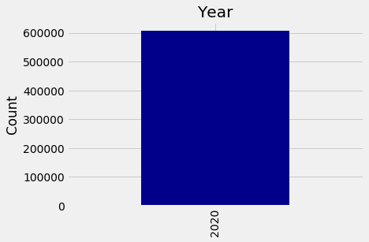

```python
df.YEAR.value_counts().plot(kind='bar', color='darkblue')
plt.ylabel("Count")
plt.title("Year");
```

### 2. Quarter and Month - All records are from the first Quarter and first Month

```python
df.QUARTER.value_counts()
```

```
1    607346
Name: QUARTER, dtype: int64
```

```python
df.MONTH.value_counts()
```

```
1    607346
Name: MONTH, dtype: int64
```

### 3. Week Days

#### - Highest number of flights is from Day 5(Friday) and 4(Thursday) which is 35% of the data .

#### - Lowest numer of flights is from Day 6(Saturday) which is 10% of overall records.

```python
print("Percentage count of each day:")
print(df.DAY_OF_WEEK.value_counts(normalize=True))
```

```
Percentage count of each day:
5    0.170927
4    0.170703
3    0.159380
1    0.135654
7    0.129261
2    0.126195
6    0.107879
Name: DAY_OF_WEEK, dtype: float64
```

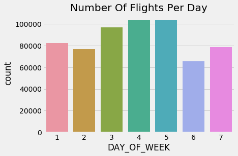

```python
sns.countplot(df.DAY_OF_WEEK)
plt.title('Number Of Flights Per Day');
```

### 4. How often do flights got cancelled?

- 7K flights got cancelled from 600K records which is only 1.1%

```python
df.CANCELLED.value_counts()
```

```
0.0    600418
1.0      6928
Name: CANCELLED, dtype: int64
```

```python
df.CANCELLED.value_counts(normalize=True)
```

```
0.0    0.988593
1.0    0.011407
Name: CANCELLED, dtype: float64
```

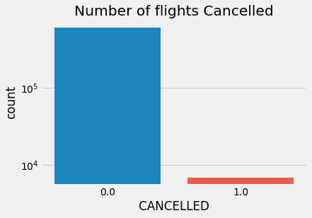

```python
g = sns.countplot(df.CANCELLED)
g.set(yscale="log")
plt.title("Number of flights Cancelled");
```

### 5. Reason Behind flight cancelled!

- Mostly due to weather ⛈
- Flights got cancelled due to security reason, curious to know what could be the issue? 🤔

(A = carrier, B = weather, C = NAS, D = security)

```python
reason_cancel = df.CANCELLATION_CODE.value_counts()
```

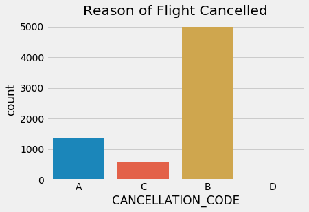

```python
sns.countplot(df.CANCELLATION_CODE)
plt.title("Reason of Flight Cancelled");
```

### 6. Diverted flights

- Very few flights got diverted. The reason behind diversion is not mentioned in dataset. Thus we cannot explore further.

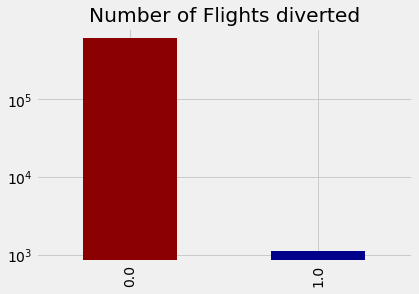

```python
df.DIVERTED.value_counts().plot(kind='bar', color=['darkred', 'darkblue'])
plt.yscale('log')
plt.title("Number of Flights diverted");
```

### 7. Flights - (Number of flights)

This feature is of no use beacuse logically same flight can never travel twice a day having same origin and destination.

```python
df.FLIGHTS.value_counts()
```

```
1.0    607346
Name: FLIGHTS, dtype: int64
```

Thus there is 607k flights with one associate with it as flights count.

### 8. Delays

Let's explore flight delays which is the most important feature of the dataset.

```python
print("Number Of Flights having 0(Zero) Departure Delay :", len(df[df.DEP_DELAY_NEW == 0]))
```

```
Number Of Flights having 0(Zero) Departure Delay : 433153
```

```python
print("Number Of Flights having 0  Arrival Delay :", len(df[df.ARR_DELAY_NEW == 0]))
```

```
Number Of Flights having 0  Arrival Delay : 437643
```

```python
df.DEP_TIME = df.DEP_TIME / 100
df.ARR_TIME = df.ARR_TIME / 100
```

```python
bins = [0, 5, 10, 16, 19, 24]
names = ['Late Night', 'Morning', 'Late Morning', 'Noon', 'Night']

df['time'] = pd.cut(df['DEP_TIME'], bins, labels=names)
```

- Arrival

```python
df.ARR_DELAY.max()
```

```
2536.0
```

```python
df.ARR_DELAY.min()
```

```
-96.0
```

- Departure

```python
df.DEP_DELAY.max()
```

```
2489.0
```

```python
df.DEP_DELAY.min()
```

```
-58.0
```

### 9. Dummy features - Flights and Unnamed:35

- Unnamed:35 contains only null values
- flights: Number of flight has only 1 as value which convveys no meaning

```python
df['Unnamed: 35']
```

```
0        NaN
1        NaN
2        NaN
3        NaN
4        NaN
          ..
607341   NaN
607342   NaN
607343   NaN
607344   NaN
607345   NaN
Name: Unnamed: 35, Length: 607346, dtype: float64
```

### Of the features you investigated, were there any unusual distributions? Did you perform any operations on the data to tidy, adjust, or change the form of the data? If so, why did you do this?

> Weather : More flights are being cancelled due to weather and very few are being delayed : we have seen under flight cancellation reason, around 5000 flights out of 7000 flights got cancelled due to bad weather conditions and but there is some strange point in delays. Very few flights got delayed due to weather conditions compared to other delays.

**Feature creation to get better insights**

## Bivariate Exploration

### 10. Relation between Flight_cancelled and days_of_week

- Maximum Flights got cancelled on 5th(friday) and 6th(saturday) day. It's obious that the max number of flights is from friday so max number of flight cancelled can be from that day too.

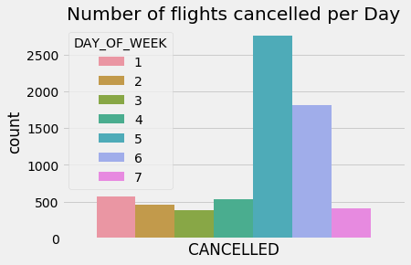

```python
sns.countplot(x="CANCELLED",hue="DAY_OF_WEEK",data=df[df.CANCELLED == 1])
plt.tick_params(bottom=False, labelbottom=False)
plt.title("Number of flights cancelled per Day");
```

### 11. When is the best time of day of week/time of year to fly to minimise delays?

- Wednesday has least delay of all days
- Noon time which is between 4-7 PM has lowest delay time

```python
df.groupby(['DAY_OF_WEEK']).DEP_DELAY.mean()
```

```
DAY_OF_WEEK
1     6.622547
2     2.856234
3     2.700872
4     5.707170
5     7.913298
6    11.898975
7     6.977587
Name: DEP_DELAY, dtype: float64
```

```python
delay_15 = df[df.DEP_DELAY>15]
```

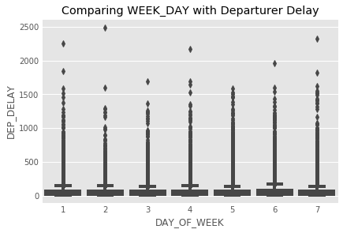

```python
plt.style.use('ggplot')
sns.boxplot(y=delay_15.DEP_DELAY, x=delay_15.DAY_OF_WEEK)
plt.title("Comparing WEEK_DAY with Departurer Delay");
```

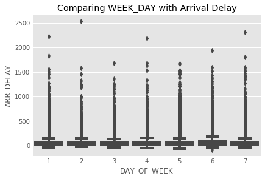

```python
sns.boxplot(y=delay_15.ARR_DELAY, x=delay_15.DAY_OF_WEEK)
plt.title("Comparing WEEK_DAY with Arrival Delay");
```

### 12. Delay vs Day

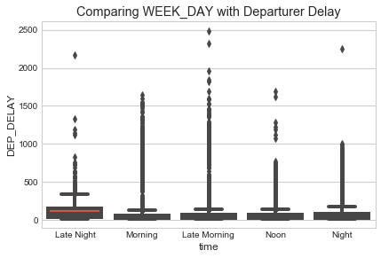

```python
plt.style.use('seaborn-whitegrid')
sns.boxplot(y=delay_15.DEP_DELAY, x=delay_15.time)
plt.title("Comparing WEEK_DAY with Departurer Delay");
```

### 13. Average Delay vs Time

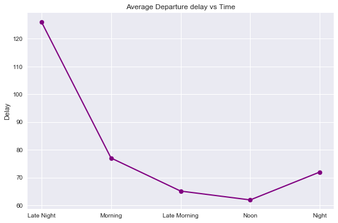

```python
plt.style.use('seaborn')
x= delay_15.groupby('time').DEP_DELAY.mean().index
y= delay_15.groupby('time').DEP_DELAY.mean().values

plt.plot(x, y, linewidth=2, marker='.', markersize=15, color='purple')
plt.ylabel('Delay')
plt.title("Average Departure delay vs Time");
```

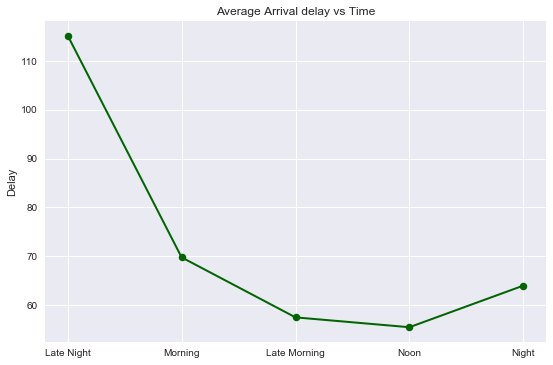

```python
x= delay_15.groupby('time').ARR_DELAY.mean().index
y= delay_15.groupby('time').ARR_DELAY.mean().values

plt.plot(x, y, linewidth=2, marker='.', markersize=15, color='darkgreen')
plt.ylabel('Delay')
plt.title("Average Arrival delay vs Time");
```

### 14. Delay greater than 15 Mins

- Average Weather delays are very small compared to carrier and late aircraft delays.
- Security delays are tend to 0 which shows that there's rare 1 or 2 security delay >15 MIN as expected.

```python
list1 = ['Weather', 'NAS', 'Carrier', 'Security', 'Late Aircraft']
list2 = []
list2.append(delay_15.WEATHER_DELAY.mean())
list2.append(delay_15.NAS_DELAY.mean())
list2.append(delay_15.CARRIER_DELAY.mean())
list2.append(delay_15.SECURITY_DELAY.mean())
list2.append(delay_15.LATE_AIRCRAFT_DELAY.mean())
```

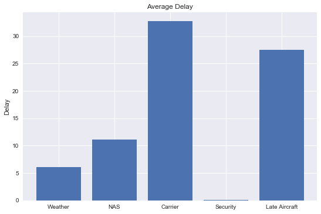

```python
plt.style.use('seaborn')
plt.title("Average Delay")
plt.ylabel("Delay")
plt.bar(x=list1, height=list2);
```

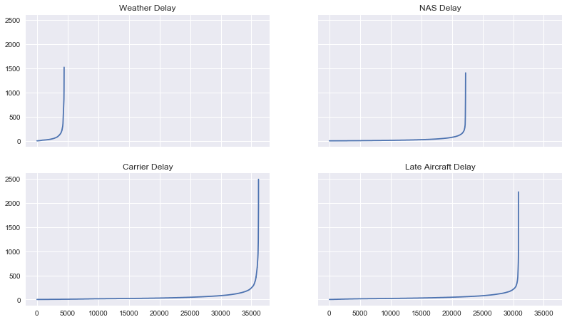

```python
fig, ax = plt.subplots(2,2,sharey=True, sharex=True, figsize=(12,7));
ax[0,0].plot(delay_15[delay_15.WEATHER_DELAY > 0].WEATHER_DELAY.sort_values().reset_index(drop=True))
ax[0,0].set_title("Weather Delay");

ax[0,1].plot(delay_15[delay_15.NAS_DELAY > 0].NAS_DELAY.sort_values().reset_index(drop=True))
ax[0,1].set_title("NAS Delay");

ax[1,0].plot(delay_15[delay_15.CARRIER_DELAY > 0].CARRIER_DELAY.sort_values().reset_index(drop=True))
ax[1,0].set_title("Carrier Delay");

ax[1,1].plot(delay_15[delay_15.LATE_AIRCRAFT_DELAY > 0].LATE_AIRCRAFT_DELAY.sort_values().reset_index(drop=True))
ax[1,1].set_title("Late Aircraft Delay");
```

- We can observe similar Pattern in all 4 delays.
- Carrier delays occurs most frequently where as weather delays are rare.
- The straight upline seen at the end of every graph indicates that Higher delays are rare in any category of delays.
- As carrier delay has smooth curve at the end which shows carrier delays have more number of higher delays.

### 15. Number of flights changing over time

- Number of late nights flights are very few whereas number of Morning and late mornings flights are almost 60% of data.

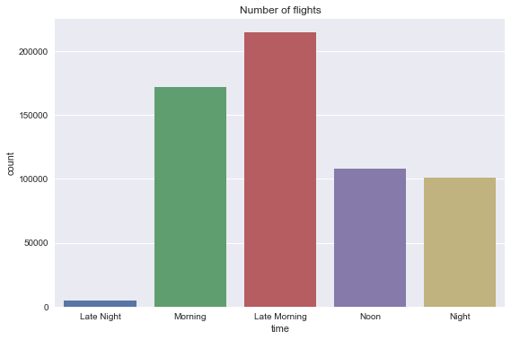

```python
sns.countplot(df.time)
plt.title("Number of flights");
```

### 16. Distance between origin and destination

- The shortest Distant flight is of 31 Miles between Wrangell,AK and Pestersburg,AK.
- The largest Distnace flight if 5095 Miles between Honolulu, HI Boston, MA.

```python
bins = [31, 100, 500, 1000, 2000, 5100]
names=['31-100', '100-500', '500-1000', '1000-2000', '2k+']

df['distance'] = pd.cut(df['DISTANCE'], bins, labels=names)
```

```python
df.DISTANCE.min()
```

```
31.0
```

```python
df.DISTANCE.max()
```

```
5095.0
```

```python
df[df.DISTANCE == 31][['DEST_CITY_NAME' , 'ORIGIN_CITY_NAME']].iloc[:2]
```

|  | DEST_CITY_NAME | ORIGIN_CITY_NAME |
| --- | --- | --- |
| 349677 | Wrangell, AK | Petersburg, AK |
| 349682 | Petersburg, AK | Wrangell, AK |

```python
df[df.DISTANCE == 5095][['DEST_CITY_NAME' , 'ORIGIN_CITY_NAME']].iloc[:1]
```

|  | DEST_CITY_NAME | ORIGIN_CITY_NAME |
| --- | --- | --- |
| 27091 | Honolulu, HI | Boston, MA |

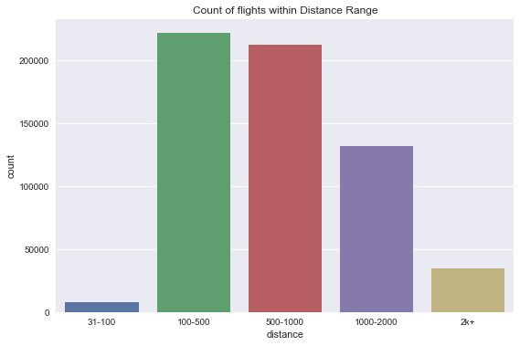

```python
sns.countplot(df.distance)
plt.title('Count of flights within Distance Range');
```

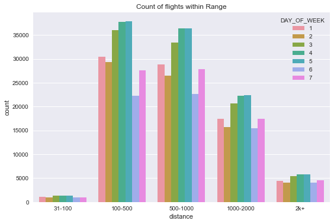

```python
sns.countplot(df.distance, hue=df.DAY_OF_WEEK)
plt.title('Count of flights within Range');
```

### 17. which states has Max number of flight a day?

- Flight from New York(NY) and Chicago(IL) has max number of flights followed by Boston(MA).

```python
df.groupby(['DEST_CITY_NAME' , 'ORIGIN_CITY_NAME'])['DAY_OF_WEEK'].value_counts().sort_values(ascending=False)[0:15]
```

```
DEST_CITY_NAME  ORIGIN_CITY_NAME  DAY_OF_WEEK
New York, NY    Chicago, IL       4              253
                                  5              252
Chicago, IL     New York, NY      4              252
                                  5              251
New York, NY    Chicago, IL       3              243
Chicago, IL     New York, NY      3              243
Boston, MA      New York, NY      4              238
                                  5              236
New York, NY    Boston, MA        4              235
                                  5              232
Boston, MA      New York, NY      3              228
New York, NY    Boston, MA        3              225
                Chicago, IL       2              216
Chicago, IL     New York, NY      2              216
New York, NY    Chicago, IL       1              211
Name: DAY_OF_WEEK, dtype: int64
```